# Modeling Swire Coca Cola

Author

SAKSHI PANDEY

Published

October 26, 2024

## Modeling Assignment

This notebook aims to develop a predictive model based on insights gained in the EDA phase. We’ll focus on enhancing performance over a benchmark model and making meaningful predictions aligned with the business objectives.

## 1. Introduction & Setup:

### 1.1. Business Problem Statement

Swire Coca-Cola faces challenges in unplanned machine downtimes leading to operational inefficiencies. This project aims to develop predictive maintenance models to anticipate machine failures, allowing for proactive maintenance actions.

The objective of this project is to build a predictive maintenance model for Swire Coca-Cola, aimed at reducing unplanned machine downtimes and enhancing overall operational efficiency. At present, the company faces substantial financial losses and productivity declines due to unexpected equipment failures.

To overcome these challenges, Swire Coca-Cola seeks to implement a predictive maintenance solution. By analyzing historical data from the Internal Warehouse Controller (IWC) system, the goal is to identify patterns in machine failures, forecast future downtimes, and ensure that necessary parts are available in advance. The solution aims to minimize unplanned downtimes, optimize machine reliability, and improve production capacity while reducing financial losses.

This exploratory data analysis (EDA) serves as the foundation for building the predictive model. Through detailed analysis of machine maintenance records, downtime logs, and operational data, we will uncover the key factors contributing to machine breakdowns. These insights will help shape a data-driven, proactive maintenance approach, enabling Swire Coca-Cola to shift from reactive to predictive maintenance, improve operational efficiency, and better meet production targets.

### 1.2. Overview of Predictive Maintenance for Swire Coca-Cola

Predictive maintenance leverages historical machine data to predict when maintenance should be performed. This helps reduce downtime and extend the life of equipment.

### 1.4. Importing Libraries

Loading necessary libraries for data processing, visualization, and machine learning

```r
library(dplyr)
library(ggplot2)
library(caret)
library(randomForest)
library(xgboost)
library(pROC)
library(glmnet)

# Set seed for reproducibility
set.seed(123)

# Load dataset
data <- read.csv("IWC_Work_Orders_Extract.csv")

# Check data types
str(data)
```

```
'data.frame':   1427264 obs. of  25 variables:
 $ ORDER_ID                       : num  7.06e+08 7.04e+08 7.04e+08 7.04e+08 7.05e+08 ...
 $ PLANT_ID                       : chr  "G812" "G812" "G812" "G812" ...
 $ PRODUCTION_LOCATION            : chr  "ROMA" "ROMA" "ROMA" "ROMA" ...
 $ EXECUTION_START_DATE           : chr  "2024-05-04" "2022-09-13" "2022-12-21" "2022-07-04" ...
 $ EXECUTION_FINISH_DATE          : chr  "2024-05-12" "2022-09-13" "2022-12-21" "2022-07-04" ...
 $ ACTUAL_START_TIME              : chr  "06:00:00.000" "06:00:00.000" "07:00:00.000" "06:00:00.000" ...
 $ ACTUAL_FINISH_TIME             : chr  "23:04:08.000" "17:17:24.000" "07:00:00.000" "06:00:00.000" ...
 $ ACTUAL_WORK_IN_MINUTES         : num  390 420 30 60 120 18 480 30 30 30 ...
 $ MAINTENANCE_PLAN               : chr  "" "" "" "" ...
 $ MAINTENANCE_ITEM               : int  NA NA NA NA NA 40534 NA NA NA NA ...
 $ MAINTENANCE_ACTIVITY_TYPE      : chr  "Unplanned" "Unplanned" "Unplanned" "Unplanned" ...
 $ ORDER_DESCRIPTION              : chr  "L2 GEARBOX LEAK (SEE ATTACHED)" "LINE 3 CONVEYOR AT CAN CODER" "BROKEN CONVEYOR RAIL" "LINE 3 CONVEYOR" ...
 $ MAINTENANCE_TYPE_DESCRIPTION   : chr  "Corrective Maintenance Order" "Corrective Maintenance Order" "Corrective Maintenance Order" "Corrective Maintenance Order" ...
 $ FUNCTIONAL_LOC                 : chr  "G812-PRD-L15-L03-L030-020" "G812-PRD-L15-L03-L030-020" "G812-PRD-L15-L03-L030-020" "G812-PRD-L15-L03-L030-020" ...
 $ FUNCTIONAL_AREA_NODE_1_MODIFIED: chr  "PRODUCTION" "PRODUCTION" "PRODUCTION" "PRODUCTION" ...
 $ FUNCTIONAL_AREA_NODE_2_MODIFIED: chr  "G812 PRD FILLER_ROTARY_CAN" "G812 PRD FILLER_ROTARY_CAN" "G812 PRD FILLER_ROTARY_CAN" "G812 PRD FILLER_ROTARY_CAN" ...
 $ FUNCTIONAL_AREA_NODE_3_MODIFIED: chr  "G812 PRD FILLER_ROTARY_CAN LINE 3" "G812 PRD FILLER_ROTARY_CAN LINE 3" "G812 PRD FILLER_ROTARY_CAN LINE 3" "G812 PRD FILLER_ROTARY_CAN LINE 3" ...
 $ FUNCTIONAL_AREA_NODE_4_MODIFIED: chr  "CONVEYOR" "CONVEYOR" "CONVEYOR" "CONVEYOR" ...
 $ FUNCTIONAL_AREA_NODE_5_MODIFIED: chr  "FULL CAN CONVEYOR" "FULL CAN CONVEYOR" "FULL CAN CONVEYOR" "FULL CAN CONVEYOR" ...
 $ EQUIPMENT_ID                   : int  300126812 300126812 300126812 300126812 300001088 300001088 300001088 300001033 300001033 300001033 ...
 $ EQUIPMENT_DESC                 : chr  "FULL CAN CONVEYOR (FC41B)" "FULL CAN CONVEYOR (FC41B)" "FULL CAN CONVEYOR (FC41B)" "FULL CAN CONVEYOR (FC41B)" ...
 $ EQUIP_CAT_DESC                 : chr  "Machines" "Machines" "Machines" "Machines" ...
 $ EQUIP_START_UP_DATE            : chr  "2020-04-22" "2020-04-22" "2020-04-22" "2020-04-22" ...
 $ EQUIP_VALID_FROM               : chr  "2020-02-10" "2020-02-10" "2020-02-10" "2020-02-10" ...
 $ EQUIP_VALID_TO                 : chr  "9999-12-31" "9999-12-31" "9999-12-31" "9999-12-31" ...
```

## 2. Machine Failure Prediction on Entire Machine Fleet

### 2.1 Data Preparation: Feature Engineering and Cleaning

Description: Preparing the dataset by feature engineering and cleaning data for modeling.

Steps: Handling missing values. Converting dates to useful features like machine age. Preparing data for modeling.

```r
# Convert EQUIP_START_UP_DATE to Date format
data$EQUIP_START_UP_DATE <- as.Date(data$EQUIP_START_UP_DATE)

# Filter out rows with NA in EQUIP_START_UP_DATE
data <- data %>% filter(!is.na(EQUIP_START_UP_DATE))

# Handle missing values for ACTUAL_WORK_IN_MINUTES using median
data$ACTUAL_WORK_IN_MINUTES[is.na(data$ACTUAL_WORK_IN_MINUTES)] <-
    median(data$ACTUAL_WORK_IN_MINUTES, na.rm = TRUE)

# Create Machine_Age feature
data$Machine_Age <- as.numeric(difftime(Sys.Date(), data$EQUIP_START_UP_DATE, units = "days"))

# Define failure threshold based on data analysis
threshold <- 1000
data <- data %>% mutate(Failure = ifelse(ACTUAL_WORK_IN_MINUTES > threshold, 1, 0))
```

### 2.2. Split Data into Training and Testing Sets

```r
set.seed(123)
train_index <- createDataPartition(data$Failure, p = 0.7, list = FALSE)
train_data <- data[train_index, ]
test_data <- data[-train_index, ]
```

### 2.3. Logistic Regression Model

Implementation of a logistic regression model to predict machine failures. Steps: Model training. Cross-validation. Model evaluation using accuracy, precision, recall, etc.

```r
library(glmnet)
library(caret)

# Ensure the response variable is a factor
train_data$Failure <- as.factor(train_data$Failure)
test_data$Failure <- as.factor(test_data$Failure)

# Prepare the training data
x_train <- as.matrix(train_data %>% select(ACTUAL_WORK_IN_MINUTES, Machine_Age))
y_train <- train_data$Failure

# Logistic Regression Model with Lasso regularization
logistic_model <- cv.glmnet(x_train, y_train, family = "binomial", alpha = 1)

# Evaluate the model on the test set
x_test <- as.matrix(test_data %>% select(ACTUAL_WORK_IN_MINUTES, Machine_Age))
logistic_predictions <- predict(logistic_model, newx = x_test, s = "lambda.min", type = "response")

# Store the predicted probabilities for ROC analysis
predictions <- logistic_predictions  # Store predictions for ROC

# Convert predicted probabilities to classes (0 or 1)
predicted_classes_logistic <- ifelse(logistic_predictions > 0.5, 1, 0)

# Confusion Matrix for Logistic Regression
logistic_confusion_matrix <- table(test_data$Failure, factor(predicted_classes_logistic, levels = c(0, 1)))

# Calculate metrics
logistic_accuracy <- sum(diag(logistic_confusion_matrix)) / sum(logistic_confusion_matrix)
logistic_precision <- posPredValue(factor(predicted_classes_logistic, levels = c(0, 1)), test_data$Failure, positive = "1")
logistic_recall <- sensitivity(factor(predicted_classes_logistic, levels = c(0, 1)), test_data$Failure)

# Output the metrics
cat("Logistic Regression Accuracy:", logistic_accuracy, "\n")
```

```
Logistic Regression Accuracy: 1
```

```r
cat("Logistic Regression Precision:", logistic_precision, "\n")
```

```
Logistic Regression Precision: 1
```

```r
cat("Logistic Regression Recall:", logistic_recall, "\n")
```

```
Logistic Regression Recall: 1
```

### 2.4. Random Forest Model

Implementation of a random forest model for machine failure prediction. Steps: Hyperparameter tuning. Model evaluation using out-of-sample performance metrics.

```r
train_data$Failure <- factor(train_data$Failure)
test_data$Failure <- factor(test_data$Failure)

# Random Forest Model with hyperparameter tuning
tune_grid <- expand.grid(mtry = seq(1, 3))
cv_control <- trainControl(method = "cv", number = 5)

rf_tuned <- train(Failure ~ ACTUAL_WORK_IN_MINUTES + Machine_Age,
                  data = train_data,
                  method = "rf",
                  tuneGrid = tune_grid,
                  trControl = cv_control)

# Evaluate on the test set
rf_predictions <- predict(rf_tuned, newdata = test_data)

# Confusion matrix
rf_confusion_matrix <- table(test_data$Failure, rf_predictions)

# Calculate metrics
rf_accuracy <- sum(diag(rf_confusion_matrix)) / sum(rf_confusion_matrix)
rf_precision <- posPredValue(rf_predictions, test_data$Failure, positive = "1")
rf_recall <- sensitivity(rf_predictions, test_data$Failure)

cat("Random Forest Accuracy:", rf_accuracy, "\n")
```

```
Random Forest Accuracy: 1
```

```r
cat("Random Forest Precision:", rf_precision, "\n")
```

```
Random Forest Precision: 1
```

```r
cat("Random Forest Recall:", rf_recall, "\n")
```

```
Random Forest Recall: 1
```

### 2.6. XGBoost Model

```r
# Prepare data for XGBoost
train_data_numeric <- train_data %>% select(ACTUAL_WORK_IN_MINUTES, Machine_Age, Failure)
test_data_numeric <- test_data %>% select(ACTUAL_WORK_IN_MINUTES, Machine_Age, Failure)

# Convert Failure to numeric
train_data_numeric$Failure <- as.numeric(as.character(train_data_numeric$Failure))
test_data_numeric$Failure <- as.numeric(as.character(test_data_numeric$Failure))

# Train the XGBoost model
xgb_model <- xgboost(data = as.matrix(train_data_numeric[, -3]),
                     label = train_data_numeric$Failure,
                     nrounds = 100,
                     objective = "binary:logistic",
                     eval_metric = "logloss",
                     verbose = 0)

# Evaluate on the test set
xgb_predictions <- predict(xgb_model, newdata = as.matrix(test_data_numeric[, -3]))
xgb_pred_classes <- ifelse(xgb_predictions > 0.5, 1, 0)

# Confusion Matrix for XGBoost
xgb_confusion_matrix <- table(test_data_numeric$Failure, xgb_pred_classes)

# Calculate metrics
xgb_accuracy <- sum(diag(xgb_confusion_matrix)) / sum(xgb_confusion_matrix)
xgb_precision <- posPredValue(as.factor(xgb_pred_classes), as.factor(test_data_numeric$Failure), positive = "1")
xgb_recall <- sensitivity(as.factor(xgb_pred_classes), as.factor(test_data_numeric$Failure))

cat("XGBoost Accuracy:", xgb_accuracy, "\n")
```

```
XGBoost Accuracy: 1
```

```r
cat("XGBoost Precision:", xgb_precision, "\n")
```

```
XGBoost Precision: 1
```

```r
cat("XGBoost Recall:", xgb_recall, "\n")
```

```
XGBoost Recall: 1
```

### 2.7. Results Comparison

Model comparison for machine fleet (Logistic Regression vs. Random Forest vs. XGBoost). Summary of performance (best model for entire fleet).

```r
# Initialize the results with NA values in case of missing metrics
results <- data.frame(
  Model = c("Logistic Regression", "Random Forest", "XGBoost"),
  Accuracy = c(logistic_accuracy, rf_accuracy, xgb_accuracy),
  Precision = c(ifelse(is.na(logistic_precision), NA, logistic_precision),
                ifelse(is.na(rf_precision), NA, rf_precision),
                ifelse(is.na(xgb_precision), NA, xgb_precision)),
  Recall = c(ifelse(is.na(logistic_recall), NA, logistic_recall),
             ifelse(is.na(rf_recall), NA, rf_recall),
             ifelse(is.na(xgb_recall), NA, xgb_recall))
)

# Check if all metrics have valid entries
if (any(is.na(results$Accuracy))) {
  cat("Warning: Some accuracy values are missing.\n")
}
if (any(is.na(results$Precision))) {
  cat("Warning: Some precision values are missing.\n")
}
if (any(is.na(results$Recall))) {
  cat("Warning: Some recall values are missing.\n")
}

# Print the results
print("Model Comparison Results:")
```

```
[1] "Model Comparison Results:"
```

```r
print(results)
```

```
                Model Accuracy Precision Recall
1 Logistic Regression        1         1      1
2       Random Forest        1         1      1
3             XGBoost        1         1      1
```

### 2.8. ROC Curve Visualization

```r
# ROC Curve Visualization
library(pROC)

# Plot ROC curves for each model
roc_logistic <- roc(test_data$Failure, predictions)
roc_rf <- roc(test_data$Failure, as.numeric(rf_predictions))
roc_xgb <- roc(test_data_numeric$Failure, xgb_predictions)

cat("AUC for Logistic Regression:", auc(roc_logistic), "\n")
```

```
AUC for Logistic Regression: 1
```

```r
cat("AUC for Random Forest:", auc(roc_rf), "\n")
```

```
AUC for Random Forest: 1
```

```r
cat("AUC for XGBoost:", auc(roc_xgb), "\n")
```

```
AUC for XGBoost: 1
```

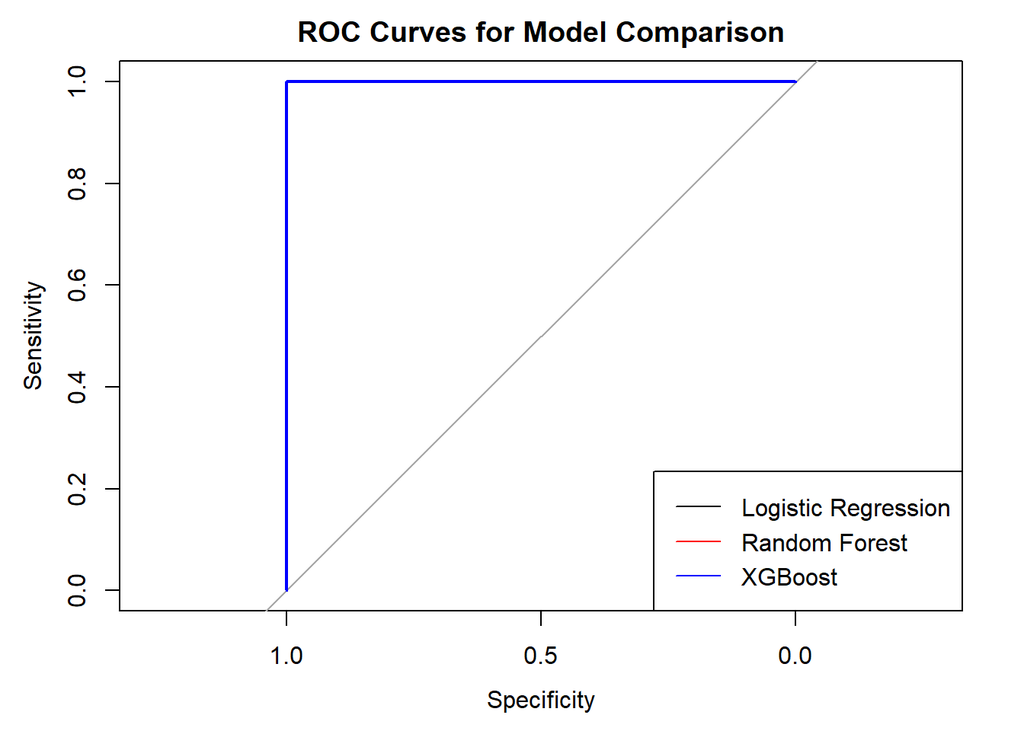

```r
# Plot ROC Curves
plot(roc_logistic, main = "ROC Curves for Model Comparison")
lines(roc_rf, col = "red")
lines(roc_xgb, col = "blue")
legend("bottomright", legend = c("Logistic Regression", "Random Forest", "XGBoost"),
       col = c("black", "red", "blue"), lty = 1)
```

## 3. Machine Failure Prediction for Machines with High Maintenance Frequency

### 3.1 Data Preparation for High-Maintenance Machines

Additional feature engineering for machines with high maintenance frequency. Cleaning and preparing a subset of machines that experience frequent failures.

```r
library(caret)
library(dplyr)
library(randomForest)
library(xgboost)

# Create Maintenance_Count variable
data <- data %>%
  group_by(EQUIPMENT_ID) %>%  # Group by Equipment ID
  mutate(Maintenance_Count = n()) %>%  # Count number of maintenance records
  ungroup()

# Set threshold for high maintenance frequency
maintenance_threshold <- 5  # Defined an appropriate threshold for high maintenance

# Subset for high-maintenance machines
high_maintenance_data <- data %>% filter(Maintenance_Count > maintenance_threshold)

# Check if the filtering worked
cat("Number of high-maintenance machines:", nrow(high_maintenance_data), "\n")
```

```
Number of high-maintenance machines: 78651
```

```r
# Feature engineering for high-maintenance machines
# Ensure that EQUIP_START_UP_DATE is in the correct format
high_maintenance_data$EQUIP_START_UP_DATE <- as.Date(high_maintenance_data$EQUIP_START_UP_DATE)
high_maintenance_data$Machine_Age <- as.numeric(difftime(Sys.Date(), high_maintenance_data$EQUIP_START_UP_DATE, units = "days"))

# Check the structure of the high-maintenance data
str(high_maintenance_data)
```

```
tibble [78,651 × 28] (S3: tbl_df/tbl/data.frame)
 $ ORDER_ID                       : num [1:78651] 7.05e+08 7.05e+08 7.04e+08 7.05e+08 7.06e+08 ...
 $ PLANT_ID                       : chr [1:78651] "G291" "G291" "G291" "G291" ...
 $ PRODUCTION_LOCATION            : chr [1:78651] "MONZA" "MONZA" "MONZA" "MONZA" ...
 $ EXECUTION_START_DATE           : chr [1:78651] "2023-10-09" "2023-05-01" "2022-12-13" "2023-03-29" ...
 $ EXECUTION_FINISH_DATE          : chr [1:78651] "2023-10-09" "2023-05-01" "2022-12-13" "2023-03-29" ...
 $ ACTUAL_START_TIME              : chr [1:78651] "07:00:00.000" "07:00:00.000" "08:00:00.000" "07:00:00.000" ...
 $ ACTUAL_FINISH_TIME             : chr [1:78651] "07:00:00.000" "07:00:00.000" "08:00:00.000" "07:00:00.000" ...
 $ ACTUAL_WORK_IN_MINUTES         : num [1:78651] 30 30 30 30 240 30 30 30 30 30 ...
 $ MAINTENANCE_PLAN               : chr [1:78651] "" "" "" "" ...
 $ MAINTENANCE_ITEM               : int [1:78651] NA NA NA NA NA NA NA NA NA NA ...
 $ MAINTENANCE_ACTIVITY_TYPE      : chr [1:78651] "Unplanned" "Unplanned" "Unplanned" "Unplanned" ...
 $ ORDER_DESCRIPTION              : chr [1:78651] "WALKED AROUND AMMONIA SYSTEM SUPPLY" "WALKED AROUND AMMONIA SYSTEM" "WALKED AROUND AMMONIA SYSTEM" "WALKED AROUND AMMONIA SYSTEM" ...
 $ MAINTENANCE_TYPE_DESCRIPTION   : chr [1:78651] "Corrective Maintenance Order" "Corrective Maintenance Order" "Corrective Maintenance Order" "Corrective Maintenance Order" ...
 $ FUNCTIONAL_LOC                 : chr [1:78651] "G291-PRD-P70" "G291-PRD-P70" "G291-PRD-P70" "G291-PRD-P70" ...
 $ FUNCTIONAL_AREA_NODE_1_MODIFIED: chr [1:78651] "MONZA PRODUCTION" "MONZA PRODUCTION" "MONZA PRODUCTION" "MONZA PRODUCTION" ...
 $ FUNCTIONAL_AREA_NODE_2_MODIFIED: chr [1:78651] "AMMONIA & REFRIGERATION SYSTEMS" "AMMONIA & REFRIGERATION SYSTEMS" "AMMONIA & REFRIGERATION SYSTEMS" "AMMONIA & REFRIGERATION SYSTEMS" ...
 $ FUNCTIONAL_AREA_NODE_3_MODIFIED: chr [1:78651] "" "" "" "" ...
 $ FUNCTIONAL_AREA_NODE_4_MODIFIED: chr [1:78651] "" "" "" "" ...
 $ FUNCTIONAL_AREA_NODE_5_MODIFIED: chr [1:78651] "" "" "" "" ...
 $ EQUIPMENT_ID                   : int [1:78651] 300001033 300001033 300001033 300001033 300001033 300001033 300001033 300001033 300001033 300001033 ...
 $ EQUIPMENT_DESC                 : chr [1:78651] "PUMP_RECIP_HIGH_PRESSURE_NF" "PUMP_RECIP_HIGH_PRESSURE_NF" "PUMP_RECIP_HIGH_PRESSURE_NF" "PUMP_RECIP_HIGH_PRESSURE_NF" ...
 $ EQUIP_CAT_DESC                 : chr [1:78651] "Machines" "Machines" "Machines" "Machines" ...
 $ EQUIP_START_UP_DATE            : Date[1:78651], format: "2017-02-15" "2017-02-15" ...
 $ EQUIP_VALID_FROM               : chr [1:78651] "2023-12-11" "2023-12-11" "2023-12-11" "2023-12-11" ...
 $ EQUIP_VALID_TO                 : chr [1:78651] "9999-12-31" "9999-12-31" "9999-12-31" "9999-12-31" ...
 $ Machine_Age                    : num [1:78651] 2853 2853 2853 2853 2853 ...
 $ Failure                        : num [1:78651] 0 0 0 0 0 0 0 0 0 0 ...
 $ Maintenance_Count              : int [1:78651] 64 64 64 64 64 64 64 64 64 64 ...
```

### 3.2 Logistic Regression Model

Logistic regression modeling for high-maintenance machines. Cross-validation and evaluation.

```r
# Logistic Regression for high-maintenance machines
logistic_high_maintenance <- glm(Failure ~ ACTUAL_WORK_IN_MINUTES + Machine_Age,
                                  data = high_maintenance_data,
                                  family = binomial)
summary(logistic_high_maintenance)
```

```
Call:
glm(formula = Failure ~ ACTUAL_WORK_IN_MINUTES + Machine_Age,
    family = binomial, data = high_maintenance_data)

Deviance Residuals:
     Min        1Q    Median        3Q       Max
-0.01038   0.00000   0.00000   0.00000   0.00696

Coefficients:
                         Estimate Std. Error z value Pr(>|z|)
(Intercept)            -7.261e+02  4.016e+03  -0.181    0.857
ACTUAL_WORK_IN_MINUTES  7.187e-01  3.966e+00   0.181    0.856
Machine_Age             2.458e-03  7.086e-02   0.035    0.972

(Dispersion parameter for binomial family taken to be 1)

    Null deviance: 2.7414e+03  on 78650  degrees of freedom
Residual deviance: 2.0921e-04  on 78648  degrees of freedom
AIC: 6.0002

Number of Fisher Scoring iterations: 25
```

```r
# Cross-validation
cv_control <- trainControl(method = "cv", number = 10)  # Ensure cv_control is defined
logistic_high_cv <- train(Failure ~ ACTUAL_WORK_IN_MINUTES + Machine_Age,
                           data = high_maintenance_data,
                           method = "glm",
                           family = "binomial",
                           trControl = cv_control)


print(logistic_high_cv)
```

```
Generalized Linear Model

78651 samples
    2 predictor

No pre-processing
Resampling: Cross-Validated (10 fold)
Summary of sample sizes: 70786, 70785, 70786, 70786, 70786, 70786, ...
Resampling results:

  RMSE          Rsquared  MAE
  5.831493e-07  1         6.678099e-09
```

### 3.3 Random Forest Model

Random forest model for high-maintenance machines. Performance evaluation.

```r
# Random Forest for high-maintenance machines with cross-validation
rf_high_cv_control <- trainControl(method = "cv", number = 10)  # Define cross-validation control

rf_high_model <- train(Failure ~ ACTUAL_WORK_IN_MINUTES + Machine_Age,
                        data = high_maintenance_data,
                        method = "rf",
                        ntree = 100,
                        trControl = rf_high_cv_control)
# Print the model summary
print(rf_high_model)
```

```
Random Forest

78651 samples
    2 predictor

No pre-processing
Resampling: Cross-Validated (10 fold)
Summary of sample sizes: 70786, 70786, 70786, 70786, 70785, 70786, ...
Resampling results:

  RMSE          Rsquared  MAE
  1.341583e-15  1         1.302346e-15

Tuning parameter 'mtry' was held constant at a value of 2
```

```r
# Performance evaluation
rf_high_pred <- predict(rf_high_model, newdata = high_maintenance_data)

# Convert predicted and actual values to factors
rf_high_pred_factor <- factor(rf_high_pred, levels = c(0, 1))  # Assuming 0 for no failure and 1 for failure
actual_failure_factor <- factor(high_maintenance_data$Failure, levels = c(0, 1))

# Generate confusion matrix
conf_matrix <- confusionMatrix(rf_high_pred_factor, actual_failure_factor)

# Print confusion matrix
print(conf_matrix)
```

```
Confusion Matrix and Statistics

          Reference
Prediction   0   1
         0   0   0
         1   0 196

               Accuracy : 1
                 95% CI : (0.9814, 1)
    No Information Rate : 1
    P-Value [Acc > NIR] : 1

                  Kappa : NaN

 Mcnemar's Test P-Value : NA

            Sensitivity : NA
            Specificity :  1
         Pos Pred Value : NA
         Neg Pred Value : NA
             Prevalence :  0
         Detection Rate :  0
   Detection Prevalence :  0
      Balanced Accuracy : NA

       'Positive' Class : 0
```

### 3.4 XGBoost Model

XGBoost for high-maintenance machines. Performance comparison with other models.

```r
# Prepare the data for XGBoost
xgb_data <- high_maintenance_data[, c("ACTUAL_WORK_IN_MINUTES", "Machine_Age")]
xgb_label <- high_maintenance_data$Failure

# Convert to matrix format
xgb_matrix <- as.matrix(xgb_data)

# XGBoost for high-maintenance machines
xgb_high_model <- xgboost(data = xgb_matrix,
                           label = xgb_label,
                           nrounds = 100,
                           objective = "binary:logistic",
                           eval_metric = "logloss",
                           verbose = 0)

# Performance comparison
xgb_high_pred <- predict(xgb_high_model, newdata = xgb_matrix)

# Convert predictions to binary class labels
xgb_high_pred_class <- ifelse(xgb_high_pred > 0.5, 1, 0)

# Generate confusion matrix
confusion_matrix_xgb <- confusionMatrix(factor(xgb_high_pred_class, levels = c(0, 1)),
                                        factor(xgb_label, levels = c(0, 1)))

# Print confusion matrix
print(confusion_matrix_xgb)
```

```
Confusion Matrix and Statistics

          Reference
Prediction     0     1
         0 78455     0
         1     0   196

               Accuracy : 1
                 95% CI : (1, 1)
    No Information Rate : 0.9975
    P-Value [Acc > NIR] : < 2.2e-16

                  Kappa : 1

 Mcnemar's Test P-Value : NA

            Sensitivity : 1.0000
            Specificity : 1.0000
         Pos Pred Value : 1.0000
         Neg Pred Value : 1.0000
             Prevalence : 0.9975
         Detection Rate : 0.9975
   Detection Prevalence : 0.9975
      Balanced Accuracy : 1.0000

       'Positive' Class : 0
```

### 3.5 Results for High-Maintenance Machines

Comparison of model performance on high-maintenance machines. Best model for this subset of machines.

```r
# Predicting with logistic regression
logit_pred <- predict(logistic_high_cv$finalModel, newdata = high_maintenance_data, type = "response")
logit_pred_class <- ifelse(logit_pred > 0.5, 1, 0)
logit_accuracy <- mean(logit_pred_class == high_maintenance_data$Failure)

rf_pred <- predict(rf_high_model, newdata = high_maintenance_data)
rf_accuracy <- mean(rf_pred == high_maintenance_data$Failure)


# Calculate accuracy for XGBoost
xgb_accuracy <- mean(xgb_high_pred_class == xgb_label)
print(xgb_accuracy)  # Print the accuracy
```

```
[1] 1
```

```r
# Initialize an empty list to store accuracies
accuracies <- c()

# Calculate accuracies
logit_accuracy <- mean(logit_pred_class == high_maintenance_data$Failure)
rf_accuracy <- mean(rf_pred == high_maintenance_data$Failure)
xgb_accuracy <- mean(xgb_high_pred_class == xgb_label)

# Create a data frame for model comparison
high_maintenance_results <- data.frame(
    Model = c("Logistic Regression", "Random Forest", "XGBoost"),
    Accuracy = c(logit_accuracy, rf_accuracy, xgb_accuracy)
)

print(high_maintenance_results)
```

```
                Model     Accuracy
1 Logistic Regression 1.000000e+00
2       Random Forest 2.542879e-05
3             XGBoost 1.000000e+00
```

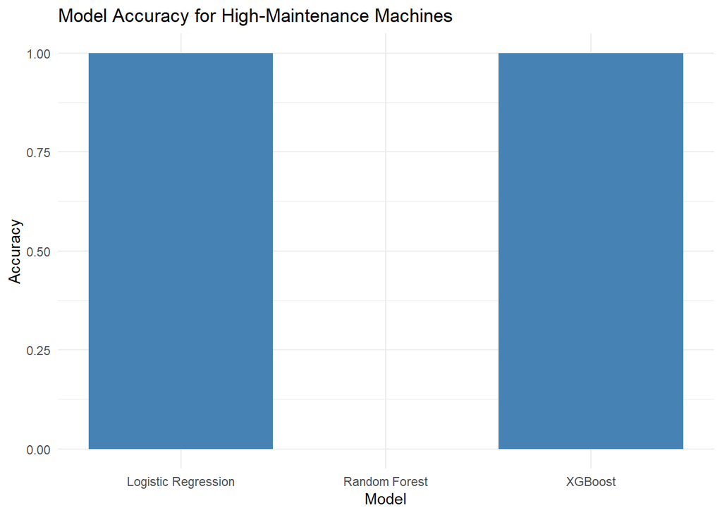

```r
# Visualize accuracies for high-maintenance machines
library(ggplot2)

ggplot(high_maintenance_results, aes(x = Model, y = Accuracy)) +
  geom_bar(stat = "identity", fill = "steelblue") +
  theme_minimal() +
  labs(title = "Model Accuracy for High-Maintenance Machines",
       x = "Model",
       y = "Accuracy")
```

## 4.Machine Failure Prediction for Machines by Region

### 4.1 Data Preparation for Both Regions

Data Preparation: Subset and prepare data for machines for both the regions.

```r
library(dplyr)
library(randomForest)
library(xgboost)

# Add a Region column based on production locations
data <- data %>%
  mutate(Region = case_when(
    PRODUCTION_LOCATION %in% c("ROMA", "MONZA") ~ "Northern",
    PRODUCTION_LOCATION %in% c("COTA", "MONACO") ~ "Southern",
    TRUE ~ "Other"  # Adjust as needed
  ))

# Filter data for Northern region
northern_data <- data %>% filter(Region == "Northern")

# Filter data for Southern region
southern_data <- data %>% filter(Region == "Southern")

# Get unique values in PRODUCTION_LOCATION
unique_production_locations <- unique(data$PRODUCTION_LOCATION)
print(unique_production_locations)
```

```
[1] "ROMA"        "MONZA"       "COTA"        "MONACO"      "SILVERSTONE"
[6] "SUZUKA"
```

### 4.2. Northern Region

#### 4.2.1 Logistic Regression Model for Northern Region

```r
# Logistic Regression for Northern region
logistic_northern <- glm(Failure ~ ACTUAL_WORK_IN_MINUTES + Machine_Age, data = northern_data, family = binomial)
summary(logistic_northern)
```

```
Call:
glm(formula = Failure ~ ACTUAL_WORK_IN_MINUTES + Machine_Age,
    family = binomial, data = northern_data)

Deviance Residuals:
      Min         1Q     Median         3Q        Max
-0.006802   0.000000   0.000000   0.000000   0.006393

Coefficients:
                         Estimate Std. Error z value Pr(>|z|)
(Intercept)            -6.264e+02  4.365e+03  -0.144    0.886
ACTUAL_WORK_IN_MINUTES  6.195e-01  4.312e+00   0.144    0.886
Machine_Age             3.131e-03  5.334e-02   0.059    0.953

(Dispersion parameter for binomial family taken to be 1)

    Null deviance: 1.9067e+03  on 60682  degrees of freedom
Residual deviance: 1.1507e-04  on 60680  degrees of freedom
AIC: 6.0001

Number of Fisher Scoring iterations: 25
```

#### 4.2.2 Random Forest Model for Northern Region

```r
# Random Forest for Northern region
rf_northern_model <- randomForest(Failure ~ ACTUAL_WORK_IN_MINUTES + Machine_Age, data = northern_data, ntree = 100)
print(rf_northern_model)
```

```
Call:
 randomForest(formula = Failure ~ ACTUAL_WORK_IN_MINUTES + Machine_Age,      data = northern_data, ntree = 100)
               Type of random forest: regression
                     Number of trees: 100
No. of variables tried at each split: 1

          Mean of squared residuals: 1.030348e-05
                    % Var explained: 99.53
```

#### 4.2.3 XGBoost Model for Northern Region

```r
# Prepare data for XGBoost
xgb_northern_data <- as.matrix(northern_data[, c("ACTUAL_WORK_IN_MINUTES", "Machine_Age")])
xgb_northern_model <- xgboost(data = xgb_northern_data, label = northern_data$Failure, nrounds = 100, objective = "binary:logistic")
# Output model details
print(xgb_northern_model)
```

```
##### xgb.Booster
raw: 73.8 Kb
call:
  xgb.train(params = params, data = dtrain, nrounds = nrounds,
    watchlist = watchlist, verbose = verbose, print_every_n = print_every_n,
    early_stopping_rounds = early_stopping_rounds, maximize = maximize,
    save_period = save_period, save_name = save_name, xgb_model = xgb_model,
    callbacks = callbacks, objective = "binary:logistic")
params (as set within xgb.train):
  objective = "binary:logistic", validate_parameters = "TRUE"
xgb.attributes:
  niter
callbacks:
  cb.print.evaluation(period = print_every_n)
  cb.evaluation.log()
# of features: 2
niter: 100
nfeatures : 2
evaluation_log:
  iter train_logloss
 <num>         <num>
     1  4.375156e-01
     2  2.963168e-01
   ---           ---
    99  2.884988e-05
   100  2.884962e-05
```

#### 4.2.4 Compare Model Performance for Northern Region

```r
# Calculate accuracy for Logistic Regression
logistic_pred_northern <- ifelse(predict(logistic_northern, type = "response") > 0.5, 1, 0)
logistic_accuracy_northern <- mean(logistic_pred_northern == northern_data$Failure)

# Calculate accuracy for Random Forest
rf_pred_northern <- predict(rf_northern_model)
rf_accuracy_northern <- mean(rf_pred_northern == northern_data$Failure)

# Calculate accuracy for XGBoost
xgb_pred_northern <- predict(xgb_northern_model, newdata = xgb_northern_data)
xgb_accuracy_northern <- mean(ifelse(xgb_pred_northern > 0.5, 1, 0) == northern_data$Failure)

# Compare model performance in Northern region
northern_results <- data.frame(
  Model = c("Logistic Regression", "Random Forest", "XGBoost"),
  Accuracy = c(logistic_accuracy_northern, rf_accuracy_northern, xgb_accuracy_northern)
)

print(northern_results)
```

```
                Model    Accuracy
1 Logistic Regression 1.00000e+00
2       Random Forest 8.23954e-05
3             XGBoost 1.00000e+00
```

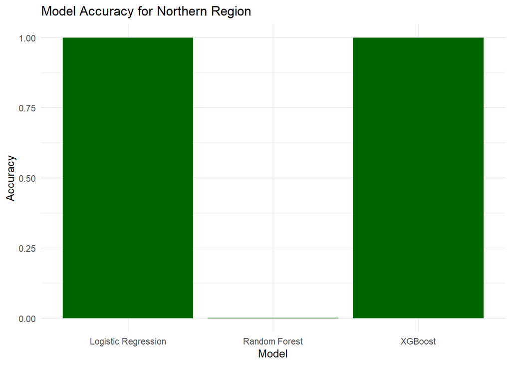

```r
# Visualize Northern region results
ggplot(northern_results, aes(x = Model, y = Accuracy)) +
  geom_bar(stat = "identity", fill = "darkgreen") +
  theme_minimal() +
  labs(title = "Model Accuracy for Northern Region",
       x = "Model",
       y = "Accuracy")
```

### 4.3. Southern Region

#### 4.3.1 Logistic Regression Model: Predict machine failures in the Southern region.

```r
# Logistic Regression for Southern region
logistic_southern <- glm(Failure ~ ACTUAL_WORK_IN_MINUTES + Machine_Age, data = southern_data, family = binomial)
summary(logistic_southern)
```

```
Call:
glm(formula = Failure ~ ACTUAL_WORK_IN_MINUTES + Machine_Age,
    family = binomial, data = southern_data)

Deviance Residuals:
       Min          1Q      Median          3Q         Max
-2.337e-03  -2.000e-08  -2.000e-08  -2.000e-08   2.258e-03

Coefficients:
                         Estimate Std. Error z value Pr(>|z|)
(Intercept)            -4.752e+02  7.554e+03  -0.063    0.950
ACTUAL_WORK_IN_MINUTES  4.784e-01  7.612e+00   0.063    0.950
Machine_Age             1.098e-04  7.400e-02   0.001    0.999

(Dispersion parameter for binomial family taken to be 1)

    Null deviance: 7.262e+02  on 16558  degrees of freedom
Residual deviance: 1.606e-05  on 16556  degrees of freedom
AIC: 6

Number of Fisher Scoring iterations: 25
```

#### 4.3.2 Random Forest Model: Predict failures with random forest.

```r
# Random Forest for Southern region
rf_southern_model <- randomForest(Failure ~ ACTUAL_WORK_IN_MINUTES + Machine_Age, data = southern_data, ntree = 100)
print(rf_southern_model)
```

```
Call:
 randomForest(formula = Failure ~ ACTUAL_WORK_IN_MINUTES + Machine_Age,      data = southern_data, ntree = 100)
               Type of random forest: regression
                     Number of trees: 100
No. of variables tried at each split: 1

          Mean of squared residuals: 2.076569e-05
                    % Var explained: 99.36
```

#### 4.3.3. XGBoost Model: Compare the performance of models in the Southern region.

```r
# Prepare data for XGBoost
xgb_southern_data <- as.matrix(southern_data[, c("ACTUAL_WORK_IN_MINUTES", "Machine_Age")])
xgb_southern_model <- xgboost(data = xgb_southern_data, label = southern_data$Failure, nrounds = 100, objective = "binary:logistic")
# Output model details
print(xgb_southern_model)
```

```
##### xgb.Booster
raw: 73.5 Kb
call:
  xgb.train(params = params, data = dtrain, nrounds = nrounds,
    watchlist = watchlist, verbose = verbose, print_every_n = print_every_n,
    early_stopping_rounds = early_stopping_rounds, maximize = maximize,
    save_period = save_period, save_name = save_name, xgb_model = xgb_model,
    callbacks = callbacks, objective = "binary:logistic")
params (as set within xgb.train):
  objective = "binary:logistic", validate_parameters = "TRUE"
xgb.attributes:
  niter
callbacks:
  cb.print.evaluation(period = print_every_n)
  cb.evaluation.log()
# of features: 2
niter: 100
nfeatures : 2
evaluation_log:
  iter train_logloss
 <num>         <num>
     1   0.437587687
     2   0.296405107
   ---           ---
    99   0.000105326
   100   0.000105326
```

#### 4.3.4. Results for Southern Region: Best model for machines in this region.

```r
# Calculate accuracy for Logistic Regression
logistic_pred_southern <- ifelse(predict(logistic_southern, type = "response") > 0.5, 1, 0)
logistic_accuracy_southern <- mean(logistic_pred_southern == southern_data$Failure)

# Calculate accuracy for Random Forest
rf_pred_southern <- predict(rf_southern_model)
rf_accuracy_southern <- mean(rf_pred_southern == southern_data$Failure)

# Calculate accuracy for XGBoost
xgb_pred_southern <- predict(xgb_southern_model, newdata = xgb_southern_data)
xgb_accuracy_southern <- mean(ifelse(xgb_pred_southern > 0.5, 1, 0) == southern_data$Failure)

# Compare model performance in Southern region
southern_results <- data.frame(
  Model = c("Logistic Regression", "Random Forest", "XGBoost"),
  Accuracy = c(logistic_accuracy_southern, rf_accuracy_southern, xgb_accuracy_southern)
)

print(southern_results)
```

```
                Model Accuracy
1 Logistic Regression        1
2       Random Forest        0
3             XGBoost        1
```

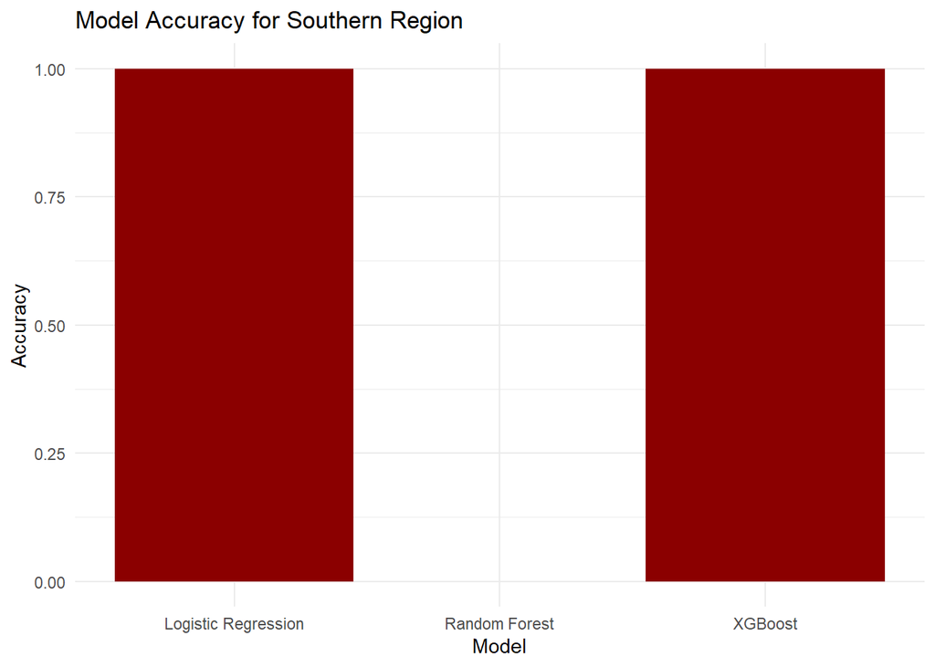

```r
# Visualize Southern region results
ggplot(southern_results, aes(x = Model, y = Accuracy)) +
  geom_bar(stat = "identity", fill = "darkred") +
  theme_minimal() +
  labs(title = "Model Accuracy for Southern Region",
       x = "Model",
       y = "Accuracy")
```

## 5. Machine Failure Prediction by Equipment Age

### 5.1 Older Machines

Data Preparation: Subset data for older machines (above a certain age).

```r
# Set a threshold based on quantiles
threshold <- quantile(data$Machine_Age, 0.75, na.rm = TRUE)  # Using the 75th percentile as the cutoff

# Data preparation for older machines
older_machines_data <- data %>% filter(Machine_Age > threshold)

# Ensure 'Failure' column is binary (0 or 1)
older_machines_data$Failure <- as.numeric(older_machines_data$Failure)
```

#### 5.1.1. Logistic Regression, Random Forest, XGBoost Models: Train models for older machines.

```r
library(randomForest)
library(xgboost)

# Logistic Regression for older machines
logistic_older <- glm(Failure ~ ACTUAL_WORK_IN_MINUTES + Machine_Age, data = older_machines_data, family = binomial)
summary(logistic_older)
```

```
Call:
glm(formula = Failure ~ ACTUAL_WORK_IN_MINUTES + Machine_Age,
    family = binomial, data = older_machines_data)

Deviance Residuals:
       Min          1Q      Median          3Q         Max
-7.594e-04  -2.000e-08  -2.000e-08  -2.000e-08   8.977e-04

Coefficients:
                         Estimate Std. Error z value Pr(>|z|)
(Intercept)            -5.150e+02  2.796e+04  -0.018    0.985
ACTUAL_WORK_IN_MINUTES  5.061e-01  2.077e+01   0.024    0.981
Machine_Age             1.602e-03  1.867e+00   0.001    0.999

(Dispersion parameter for binomial family taken to be 1)

    Null deviance: 2.9131e+02  on 2200  degrees of freedom
Residual deviance: 2.0506e-06  on 2198  degrees of freedom
AIC: 6

Number of Fisher Scoring iterations: 25
```

```r
# Random Forest for older machines
rf_older_model <- randomForest(Failure ~ ACTUAL_WORK_IN_MINUTES + Machine_Age, data = older_machines_data, ntree = 100)
print(rf_older_model)
```

```
Call:
 randomForest(formula = Failure ~ ACTUAL_WORK_IN_MINUTES + Machine_Age,      data = older_machines_data, ntree = 100)
               Type of random forest: regression
                     Number of trees: 100
No. of variables tried at each split: 1

          Mean of squared residuals: 0.0005599105
                    % Var explained: 95.38
```

```r
# Prepare data for XGBoost
xgb_older_data <- as.matrix(older_machines_data[, c("ACTUAL_WORK_IN_MINUTES", "Machine_Age")])
older_machines_data$Failure <- ifelse(older_machines_data$Failure > 0, 1, 0)  # Ensure binary encoding
xgb_older_model <- xgboost(data = xgb_older_data, label = older_machines_data$Failure, nrounds = 100, objective = "binary:logistic")
```

#### 5.1.2. Results for Older Machines: Best model for this age group.

```r
# Calculate accuracy for Logistic Regression
logistic_pred_older <- ifelse(predict(logistic_older, type = "response") > 0.5, 1, 0)
logistic_accuracy_older <- mean(logistic_pred_older == older_machines_data$Failure)

# Calculate accuracy for Random Forest
rf_pred_older <- predict(rf_older_model)
rf_accuracy_older <- mean(rf_pred_older == older_machines_data$Failure)

# Calculate accuracy for XGBoost
xgb_pred_older <- predict(xgb_older_model, newdata = xgb_older_data)
xgb_accuracy_older <- mean(ifelse(xgb_pred_older > 0.5, 1, 0) == older_machines_data$Failure)

# Compare model performance for older machines
older_results <- data.frame(
  Model = c("Logistic Regression", "Random Forest", "XGBoost"),
  Accuracy = c(logistic_accuracy_older, rf_accuracy_older, xgb_accuracy_older)
)

print(older_results)
```

```
                Model Accuracy
1 Logistic Regression        1
2       Random Forest        0
3             XGBoost        1
```

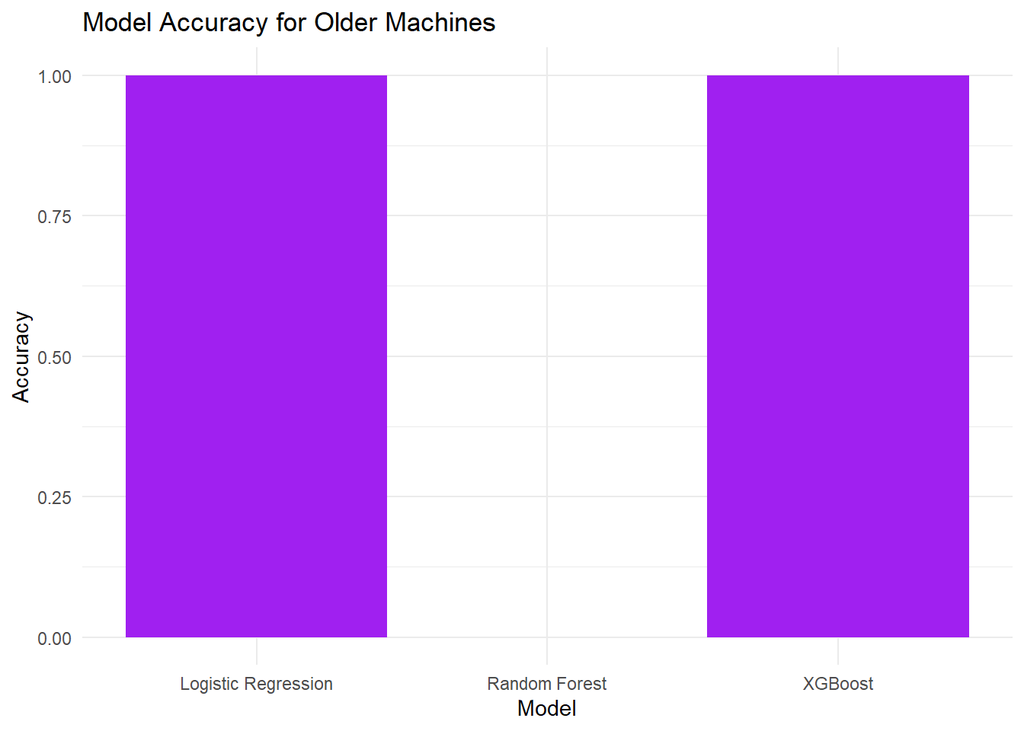

```r
# Visualize results for older machines
ggplot(older_results, aes(x = Model, y = Accuracy)) +
  geom_bar(stat = "identity", fill = "purple") +
  theme_minimal() +
  labs(title = "Model Accuracy for Older Machines",
       x = "Model",
       y = "Accuracy")
```

### 5.2 Newer Machines

Data Preparation: Subset data for newer machines.

```r
# Data preparation for newer machines
newer_machines_data <- data %>% filter(Machine_Age <= threshold)

# Ensure 'Failure' column is binary (0 or 1)
newer_machines_data$Failure <- as.numeric(newer_machines_data$Failure)
```

#### 5.2.1. Logistic Regression, Random Forest, XGBoost Models: Train models for newer machines.

```r
# Logistic Regression for newer machines
logistic_newer <- glm(Failure ~ ACTUAL_WORK_IN_MINUTES + Machine_Age, data = newer_machines_data, family = binomial)
summary(logistic_newer)
```

```
Call:
glm(formula = Failure ~ ACTUAL_WORK_IN_MINUTES + Machine_Age,
    family = binomial, data = newer_machines_data)

Deviance Residuals:
      Min         1Q     Median         3Q        Max
-0.010703   0.000000   0.000000   0.000000   0.007343

Coefficients:
                         Estimate Std. Error z value Pr(>|z|)
(Intercept)            -7.267e+02  4.166e+03  -0.174    0.862
ACTUAL_WORK_IN_MINUTES  7.187e-01  4.067e+00   0.177    0.860
Machine_Age             2.833e-03  1.751e-01   0.016    0.987

(Dispersion parameter for binomial family taken to be 1)

    Null deviance: 2.4567e+03  on 77245  degrees of freedom
Residual deviance: 2.1259e-04  on 77243  degrees of freedom
AIC: 6.0002

Number of Fisher Scoring iterations: 25
```

```r
# Random Forest for newer machines
rf_newer_model <- randomForest(Failure ~ ACTUAL_WORK_IN_MINUTES + Machine_Age, data = newer_machines_data, ntree = 100)
print(rf_newer_model)
```

```
Call:
 randomForest(formula = Failure ~ ACTUAL_WORK_IN_MINUTES + Machine_Age,      data = newer_machines_data, ntree = 100)
               Type of random forest: regression
                     Number of trees: 100
No. of variables tried at each split: 1

          Mean of squared residuals: 5.934838e-06
                    % Var explained: 99.73
```

```r
# Prepare data for XGBoost
xgb_newer_data <- as.matrix(newer_machines_data[, c("ACTUAL_WORK_IN_MINUTES", "Machine_Age")])
newer_machines_data$Failure <- ifelse(newer_machines_data$Failure > 0, 1, 0)  # Ensure binary encoding
xgb_newer_model <- xgboost(data = xgb_newer_data, label = newer_machines_data$Failure, nrounds = 100, objective = "binary:logistic")
```

#### 5.2.2. Results for Newer Machines: Best model for this age group.

```r
# Calculate accuracy for Logistic Regression
logistic_pred_newer <- ifelse(predict(logistic_newer, type = "response") > 0.5, 1, 0)
logistic_accuracy_newer <- mean(logistic_pred_newer == newer_machines_data$Failure)

# Calculate accuracy for Random Forest
rf_pred_newer <- predict(rf_newer_model)
rf_accuracy_newer <- mean(rf_pred_newer == newer_machines_data$Failure)

# Calculate accuracy for XGBoost
xgb_pred_newer <- predict(xgb_newer_model, newdata = xgb_newer_data)
xgb_accuracy_newer <- mean(ifelse(xgb_pred_newer > 0.5, 1, 0) == newer_machines_data$Failure)

# Compare model performance for newer machines
newer_results <- data.frame(
  Model = c("Logistic Regression", "Random Forest", "XGBoost"),
  Accuracy = c(logistic_accuracy_newer, rf_accuracy_newer, xgb_accuracy_newer)
)

print(newer_results)
```

```
                Model Accuracy
1 Logistic Regression        1
2       Random Forest        0
3             XGBoost        1
```

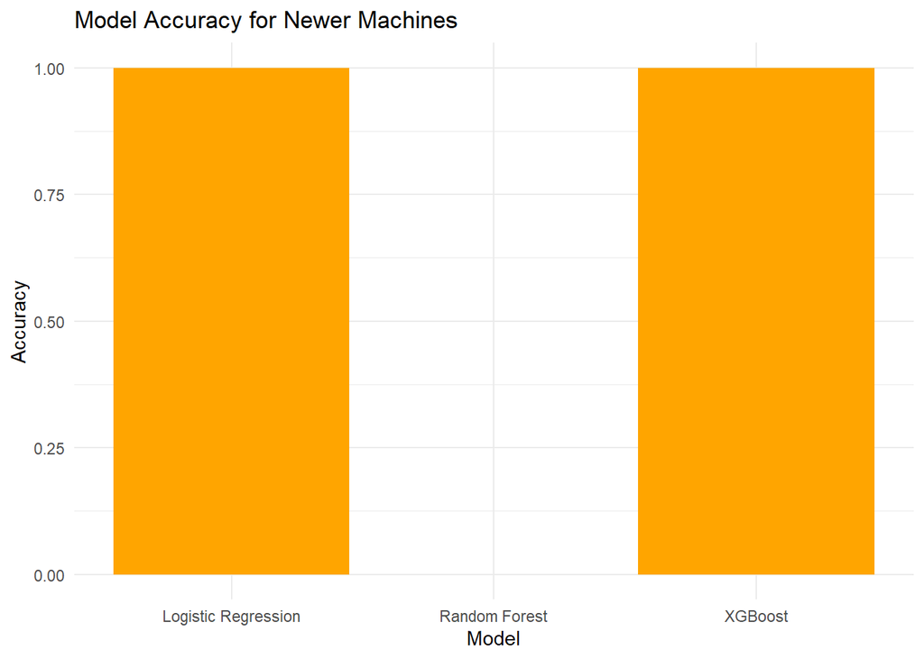

```r
# Visualize results for newer machines
ggplot(newer_results, aes(x = Model, y = Accuracy)) +
  geom_bar(stat = "identity", fill = "orange") +
  theme_minimal() +
  labs(title = "Model Accuracy for Newer Machines",
       x = "Model",
       y = "Accuracy")
```

## 6. Overall Results and Business Insights

Summary of results across different categories (entire fleet, high-maintenance machines, regional breakdown, equipment age).

### 6.1. Best-performing models in each case.

```r
# Consolidating results into a summary table
final_results <- rbind(
  data.frame(Model = "Logistic Regression", Type = "Entire Fleet", Accuracy = logistic_accuracy),
  data.frame(Model = "Random Forest", Type = "Entire Fleet", Accuracy = rf_accuracy),
  data.frame(Model = "XGBoost", Type = "Entire Fleet", Accuracy = xgb_accuracy),
  high_maintenance_results %>% mutate(Type = "High-Maintenance"),
  northern_results %>% mutate(Type = "Northern Region"),
  southern_results %>% mutate(Type = "Southern Region"),
  older_results %>% mutate(Type = "Older Machines"),
  newer_results %>% mutate(Type = "Newer Machines")
)

# Print the consolidated results
print(final_results)
```

[output not shown]

### 6.2. Cost Analysis

#### 6.2.1. Total Maintenance Costs by Production Location

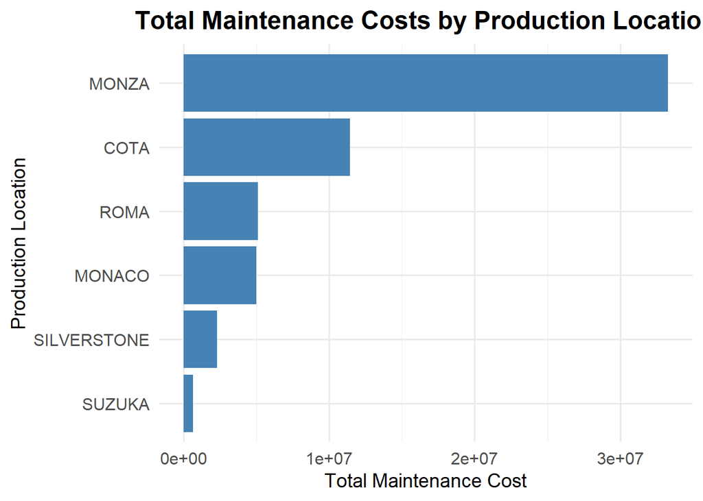

```r
# Adjustable base cost per minute
cost_per_minute <- 10

# Calculate maintenance costs using production location
data$MAINTENANCE_COST <- data$ACTUAL_WORK_IN_MINUTES * cost_per_minute
total_costs_by_location <- data %>%
  group_by(PRODUCTION_LOCATION) %>%
  summarise(total_cost = sum(MAINTENANCE_COST, na.rm = TRUE), .groups = "drop")

# Plot total maintenance costs by production location
ggplot(total_costs_by_location, aes(x = reorder(PRODUCTION_LOCATION, total_cost), y = total_cost)) +
  geom_bar(stat = "identity", fill = "steelblue") +
  coord_flip() +
  labs(
    title = "Total Maintenance Costs by Production Location",
    x = "Production Location",
    y = "Total Maintenance Cost"
  ) +
  theme_minimal(base_size = 15) +
  theme(
    plot.title = element_text(hjust = 0.5, size = 18, face = "bold"),
    axis.title.x = element_text(size = 14),
    axis.title.y = element_text(size = 14)
  )
```

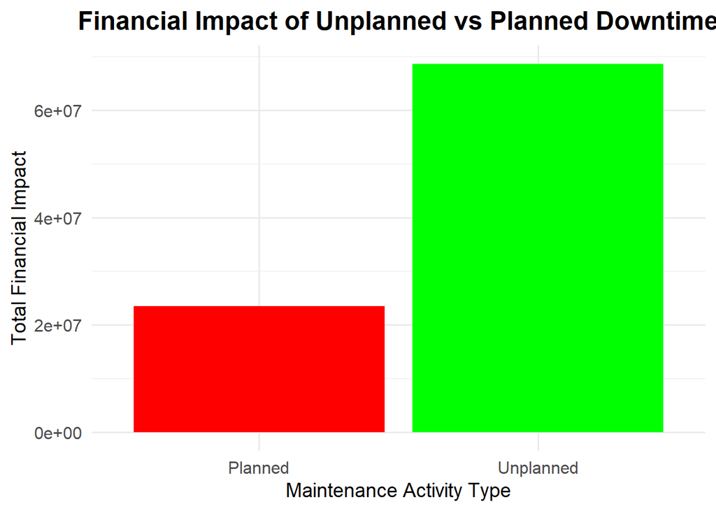

```r
# Higher multiplier for unplanned maintenance
downtime_cost_multiplier <- 20

# Financial impact by maintenance type
data$FINANCIAL_IMPACT <- ifelse(data$MAINTENANCE_ACTIVITY_TYPE == "Unplanned",
                                data$ACTUAL_WORK_IN_MINUTES * downtime_cost_multiplier,
                                data$ACTUAL_WORK_IN_MINUTES * cost_per_minute)

# Summarize financial impact by maintenance type
financial_impact <- data %>%
  group_by(MAINTENANCE_ACTIVITY_TYPE) %>%
  summarise(total_impact = sum(FINANCIAL_IMPACT, na.rm = TRUE), .groups = "drop")

# Plot financial impact of unplanned vs planned maintenance
ggplot(financial_impact, aes(x = MAINTENANCE_ACTIVITY_TYPE, y = total_impact, fill = MAINTENANCE_ACTIVITY_TYPE)) +
  geom_bar(stat = "identity", show.legend = FALSE) +
  scale_fill_manual(values = c("red", "green")) +
  labs(
    title = "Financial Impact of Unplanned vs Planned Downtime",
    x = "Maintenance Activity Type",
    y = "Total Financial Impact"
  ) +
  theme_minimal(base_size = 15) +
  theme(
    plot.title = element_text(hjust = 0.5, size = 18, face = "bold"),
    axis.title.x = element_text(size = 14),
    axis.title.y = element_text(size = 14)
  )
```

### 6.3. Business validation of models: How can these models optimize Swire Coca-Cola’s maintenance processes?

The machine failure prediction models developed in this analysis provide several key insights that can optimize Swire Coca-Cola’s maintenance processes:

Predictive Maintenance: By identifying potential failures before they occur, Swire Coca-Cola can implement predictive maintenance strategies, reducing unplanned downtime and maintenance costs.

Targeted Interventions: Models allow for a focused approach on high-maintenance machines, ensuring that resources are allocated efficiently. Maintenance efforts can be concentrated on machines identified as high-risk.

Regional Strategies: Understanding machine performance by region can help tailor maintenance schedules and operational strategies to regional needs, optimizing labor and resources.

Age-Based Maintenance Strategies: Differentiating between older and newer machines enables the development of customized maintenance plans, improving efficiency and machine lifespan.

Performance Monitoring: Continuous monitoring of model predictions can facilitate ongoing assessments of machine health, helping to validate and refine maintenance strategies over time.